# Exo_suppl_beers

Kevin Missault

30/01/2019

# Load packages

```r
library(readr)
library(dplyr)
library(tidyr)
library(ggplot2)
library(lubridate)
```

# Read file

Read file and add delim option or use read_csv2() for ; as separator and , for the decimal point (common in European countries). This table was created for the exercice. It’s not real data. You can see the beer consumption (Liter) per year at different age according to working statue and gender.

```r
beers_data <- read_delim("Data/Beers.csv", ";")
str(beers_data)
```

```
## Classes 'spec_tbl_df', 'tbl_df', 'tbl' and 'data.frame': 48 obs. of  8 variables:
##  $ Record_ID  : num  1 2 3 4 5 6 7 8 9 10 ...
##  $ Work       : chr  "Employed" "Employed" "Employed" "Employed" ...
##  $ Consumption: num  100 110 120 150 155 153 175 190 200 180 ...
##  $ Gender     : chr  "Male" "Male" "Male" "Male" ...
##  $ Age        : num  25 25 25 35 35 35 45 45 45 55 ...
##  $ Day        : num  1 2 3 4 1 2 5 19 24 15 ...
##  $ Month      : num  7 8 7 7 9 10 11 8 9 1 ...
##  $ Year       : num  2017 2017 2017 2017 2017 ...
##  - attr(*, "spec")=
##   .. cols(
##   ..   Record_ID = col_double(),
##   ..   Work = col_character(),
##   ..   Consumption = col_double(),
##   ..   Gender = col_character(),
##   ..   Age = col_double(),
##   ..   Day = col_double(),
##   ..   Month = col_double(),
##   ..   Year = col_double()
##   .. )
```

# Remove NA data

```r
is.na(beers_data)
```

[output not shown]

[output cut: 34 more lines]

```r
beers_data_filter <- beers_data %>%
  filter(!is.na(Consumption))
beers_data_filter
```

```
## # A tibble: 47 x 8
##    Record_ID Work     Consumption Gender   Age   Day Month  Year
##        <dbl> <chr>          <dbl> <chr>  <dbl> <dbl> <dbl> <dbl>
##  1         1 Employed         100 Male      25     1     7  2017
##  2         2 Employed         110 Male      25     2     8  2017
##  3         3 Employed         120 Male      25     3     7  2017
##  4         4 Employed         150 Male      35     4     7  2017
##  5         5 Employed         155 Male      35     1     9  2017
##  6         6 Employed         153 Male      35     2    10  2017
##  7         7 Employed         175 Male      45     5    11  2017
##  8         8 Employed         190 Male      45    19     8  2017
##  9         9 Employed         200 Male      45    24     9  2017
## 10        10 Employed         180 Male      55    15     1  2017
## # … with 37 more rows
```

# Mutate for date

Create a column Date using mutate from dplyr. What is the class of Date ?

```r
beers_data_filter %>%
  mutate(Date = paste(beers_data_filter$Year, beers_data_filter$Month, beers_data_filter$Day, sep = "-"))
```

```
## # A tibble: 47 x 9
##    Record_ID Work     Consumption Gender   Age   Day Month  Year Date
##        <dbl> <chr>          <dbl> <chr>  <dbl> <dbl> <dbl> <dbl> <chr>
##  1         1 Employed         100 Male      25     1     7  2017 2017-7-1
##  2         2 Employed         110 Male      25     2     8  2017 2017-8-2
##  3         3 Employed         120 Male      25     3     7  2017 2017-7-3
##  4         4 Employed         150 Male      35     4     7  2017 2017-7-4
##  5         5 Employed         155 Male      35     1     9  2017 2017-9-1
##  6         6 Employed         153 Male      35     2    10  2017 2017-10-2
##  7         7 Employed         175 Male      45     5    11  2017 2017-11-5
##  8         8 Employed         190 Male      45    19     8  2017 2017-8-19
##  9         9 Employed         200 Male      45    24     9  2017 2017-9-24
## 10        10 Employed         180 Male      55    15     1  2017 2017-1-15
## # … with 37 more rows
```

# Lubridate for date

Create a column Date using lubridate. What is the class of Date ?

```r
beers_data_filter$Date <- ymd(paste(beers_data_filter$Year, beers_data_filter$Month, beers_data_filter$Day, sep = "-"))
str(beers_data_filter)
```

```
## Classes 'tbl_df', 'tbl' and 'data.frame':    47 obs. of  9 variables:
##  $ Record_ID  : num  1 2 3 4 5 6 7 8 9 10 ...
##  $ Work       : chr  "Employed" "Employed" "Employed" "Employed" ...
##  $ Consumption: num  100 110 120 150 155 153 175 190 200 180 ...
##  $ Gender     : chr  "Male" "Male" "Male" "Male" ...
##  $ Age        : num  25 25 25 35 35 35 45 45 45 55 ...
##  $ Day        : num  1 2 3 4 1 2 5 19 24 15 ...
##  $ Month      : num  7 8 7 7 9 10 11 8 9 1 ...
##  $ Year       : num  2017 2017 2017 2017 2017 ...
##  $ Date       : Date, format: "2017-07-01" "2017-08-02" ...
##  - attr(*, "spec")=
##   .. cols(
##   ..   Record_ID = col_double(),
##   ..   Work = col_character(),
##   ..   Consumption = col_double(),
##   ..   Gender = col_character(),
##   ..   Age = col_double(),
##   ..   Day = col_double(),
##   ..   Month = col_double(),
##   ..   Year = col_double()
##   .. )
```

# Filter, select and arrange + export data

```r
exported_table <- beers_data_filter %>%
  filter(Age > 35) %>%
  filter(Gender == "Female") %>%
  filter(Work == "Employed") %>%
  select(-Age, -Day, -Month, -Year) %>%
  arrange(desc(Consumption))

write_csv(exported_table, path = "Data_output/exported_table.csv")

read_csv("Data_output/exported_table.csv")
```

```
## # A tibble: 6 x 5
##   Record_ID Work     Consumption Gender Date
##       <dbl> <chr>          <dbl> <chr>  <date>
## 1        21 Employed         180 Female 2017-04-21
## 2        20 Employed         175 Female 2017-02-19
## 3        19 Employed         170 Female 2017-11-16
## 4        24 Employed         140 Female 2017-09-16
## 5        23 Employed         125 Female 2017-08-07
## 6        22 Employed         120 Female 2017-06-22
```

# Analysing data

Does working statue have an impact on beer consumption ?

```r
beers_data_filter %>%
  group_by(Work) %>%
  summarize(mean_consumption = mean(Consumption))
```

```
## # A tibble: 2 x 2
##   Work       mean_consumption
##   <chr>                 <dbl>
## 1 Employed               172.
## 2 Unemployed             189
```

Do men drink more beers than women ?

```r
beers_data_filter %>%
  group_by(Gender) %>%
  summarize(mean_consumption = mean(Consumption))
```

```
## # A tibble: 2 x 2
##   Gender mean_consumption
##   <chr>             <dbl>
## 1 Female             165.
## 2 Male               195.
```

Does working statue have an influence on beer consumption according to gender ?

```r
beers_data_filter %>%
  group_by(Gender, Work) %>%
  summarize(mean_consumption = mean(Consumption))
```

```
## # A tibble: 4 x 3
## # Groups:   Gender [?]
##   Gender Work       mean_consumption
##   <chr>  <chr>                 <dbl>
## 1 Female Employed               178.
## 2 Female Unemployed             151.
## 3 Male   Employed               165.
## 4 Male   Unemployed             224
```

Do men drink more than women according to age and working statue ? Write code to get the following plot.

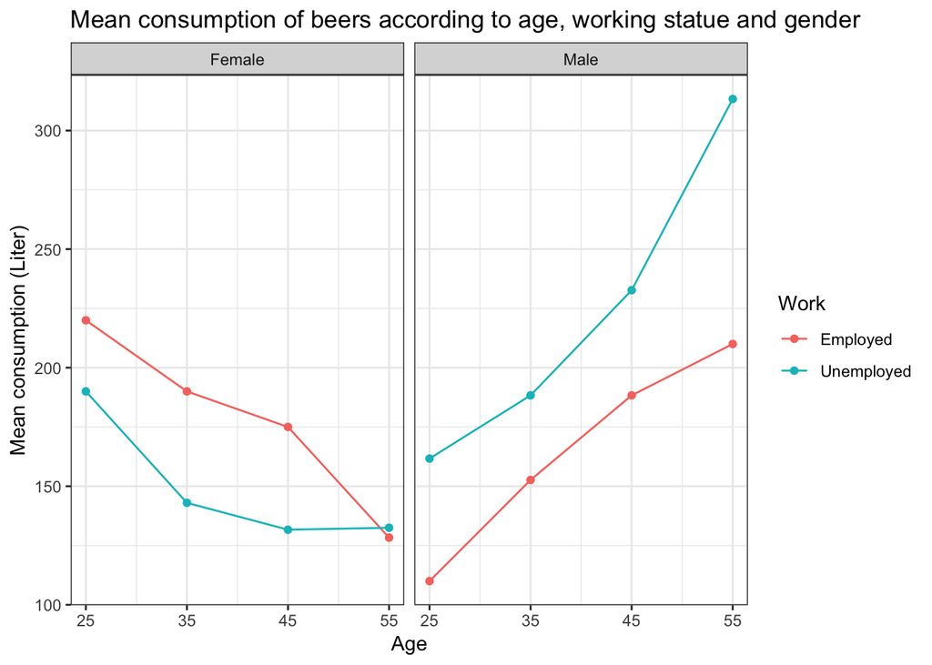